# Commercial Goals: Vehicle Traffic

Utilizing Synthetic Controls to Baseline Projected Performance

Insights and Analytics | Last Updated: 28 January, 2022

# Top Line

We built a forecast model to set a useful baseline for the business to build from. The business owner for this metric will ultimately set where were they want the business goal to land.

- **Model 1 (Low):** Covid data included, and covid period counted as 3/1/2020 - 5/1/2021
  - This model produces the smallest forecasted traffic, due to the impact of the negative trend.
- **Model 2 (Mid-point):** Covid data included, leveled negative growth trend
  - This model producess a forecasted traffic that is close to 2021 traffic.
- **Model 3 (High):** Covid data not included (then forecast 3 years out)
  - This model essentially is built with the belief that the trends pre-2020 will continue. Ultimately the business question here is whether shopper behavior will fully return to pre-pandemic behaviors in 2022.

|  | 2017 | 2018 | 2019 | 2020 | 2021 | 2022<sup>1</sup> | 2022FC_High | 2022FC_Low | 2022FC_Mid | Business Goal |
| --- | --- | --- | --- | --- | --- | --- | --- | --- | --- | --- |
| Jan | 3.77M | 3.70M | 3.85M | 4.00M | 3.82M | 3.11M | 4.27M | 4.06M | 4.09M | TBD |
| Feb | 3.84M | 3.80M | 3.78M | 4.17M | 3.26M | - | 4.12M | 3.80M | 3.88M | TBD |
| Mar | 4.56M | 4.95M | 4.96M | 2.64M | 4.93M | - | 5.07M | 4.66M | 4.72M | TBD |
| Apr | 4.81M | 4.55M | 4.79M | 0.53M | 4.69M | - | 5.10M | 4.21M | 4.36M | TBD |
| May | 4.85M | 4.99M | 5.06M | 2.22M | 5.02M | - | 5.28M | 4.28M | 4.60M | TBD |
| Jun | 4.87M | 5.12M | 5.19M | 4.23M | 5.05M | - | 5.32M | 4.59M | 5.01M | TBD |
| Jul | 5.63M | 5.66M | 5.66M | 4.65M | 5.71M | - | 6.11M | 5.17M | 5.71M | TBD |
| Aug | 5.44M | 5.71M | 5.90M | 4.82M | 5.50M | - | 5.95M | 4.92M | 5.58M | TBD |
| Sep | 4.52M | 4.46M | 4.45M | 4.40M | 4.64M | - | 4.75M | 3.86M | 4.59M | TBD |
| Oct | 4.67M | 4.68M | 4.79M | 4.48M | 5.00M | - | 5.15M | 4.07M | 4.92M | TBD |
| Nov | 5.38M | 5.47M | 5.60M | 4.71M | 5.36M | - | 5.61M | 4.41M | 5.28M | TBD |
| Dec | 6.40M | 6.46M | 6.33M | 5.81M | 6.43M | - | 6.57M | 5.62M | 6.56M | TBD |
| total | 58.74M | 59.56M | 60.35M | 46.68M | 59.41M | — | 63.29M | 53.66M | 59.29M | — |

<sup>*1*</sup> Note that 2022 actuals represent the current traffic and is not a complete month

# Reviewing Historical Data

## Overview of Data

### Data Generation

Traffic data, as measured via axle counters at each center. These counters are then read and manually entered by the center teams into OpsStats.

- Note that traffic will not contain data for Atlantic City as we do not have a traffic counter at that center.
- Business practices is that traffic can be edited for the prior month up to the 7th of the current month.

### Data Pull from DB

For forecasting purposes we have pulled data for all centers from 2016 until now (2022.01.26).

**Source:** OpsStats (server: SQLPROD)

**Tables:** [OpsStats].[dbo].[tblTraffic] + [OpsStats].[dbo].[tblPeopleTraffic]

- Foxwoods is removed from vehicle traffic table
- Only Foxwoods to pulled from people traffic table
  - Note that the business assumption of “3 person : 1 car” ratio is applied to transform the people counts to car counts

## View of Trends

Before we begin to model this work, we want to visualize the general trends. This allows us to to flag for large outliers or anomalies within our data.

- With this data we can see how significant Covid shutdowns had on traffic throughout 2020.
- We also see a fairly consistent month to month seasonal variation.

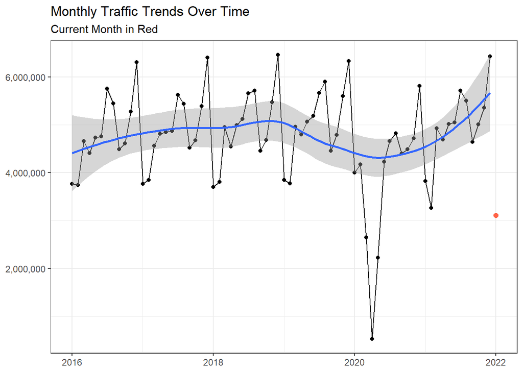

### Monthly View

Each color line represents a different year’s worth of traffic aggregated on a monthly basis.

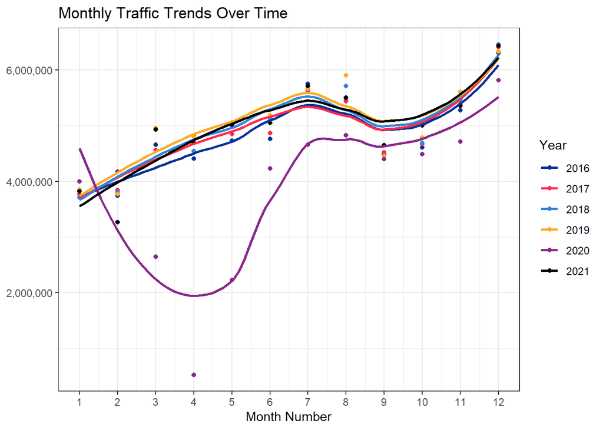

# Forcasting model

## Why Synthetic Controls?

*This method can account for the effects of confounders changing over time, by weighting the control group to better match the treatment group before the intervention. Another advantage of the synthetic control method is that it allows researchers to systematically select comparison groups. It has been applied to the fields of political science, health policy, criminology, and economics.*

In our case, we are using this methodology to help set a baseline of where the business would be if we continue with the same historical processes and procedures as before.

## Step 1: Build Forecast Model

Building model for all entire portfolio.

- In this case, we are already into 2022, but we want to build the forecast model excluding the new year.
- In the future data frame, we go forwards 365 days (1 year) to be able to predict against.

```r
Traffc <-
  CleanTraffc %>%
  filter(Date < as.Date("2022-01-01")) %>%
  mutate(ds = Date) %>%
  group_by(ds) %>%
  summarise(y = sum(traffic, na.rm=T)) %>%
  ungroup()

# m <- prophet(Traffc, holidays = covid)
m <- prophet(holidays = covid)
m <- add_country_holidays(m, country_name = 'US')
m <- fit.prophet(m, Traffc)

future <- make_future_dataframe(m, periods = 365)
# tail(future)


forecast <- predict(m, future)
# tail(forecast[c('ds', 'yhat', 'yhat_lower', 'yhat_upper')])
```

## Forecast Results

Below is the forecast model.

We see a strong degree of seasonality

### Forecast Model 1

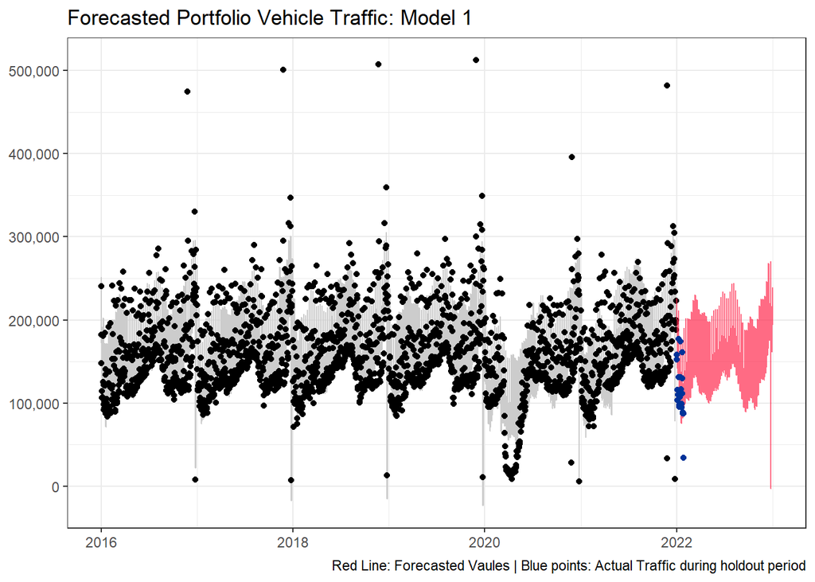

### Forecast Model 2

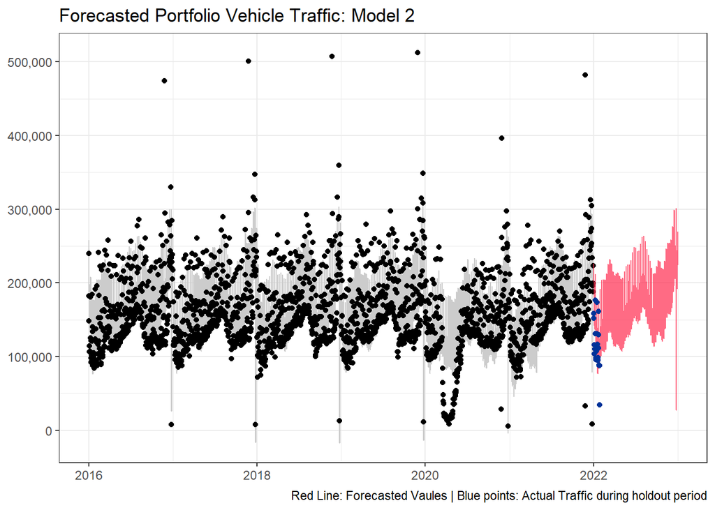

### Forecast Model 3

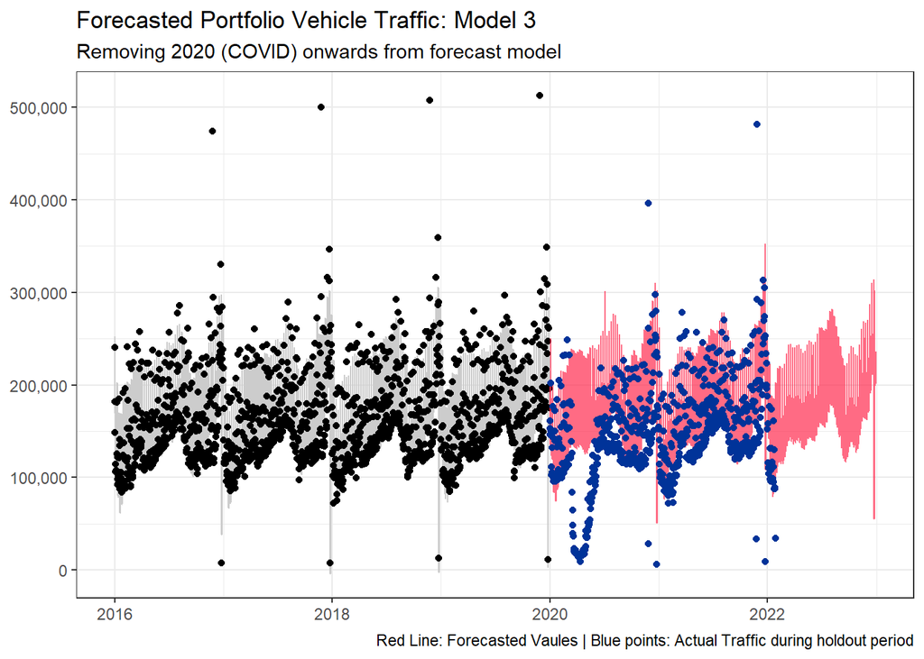

### Forecast Components

A forecast model can be broken up into the different elements that add (or multiply) together. By splitting them out and visualizing them, we then can view the index values and assess the impact of different items on the results

By breaking down the forecast into it’s component parts we see a couple of things:

**Note about negative values:** These 4 items below are added together to create the forecast model. This is why there are some items that are negative and some that are positive. A negative value does not mean that we would forecast negative vehicles, but instead that at those instances the traffic would decrease from the trend.

- An example here would be the impact of Christmas day on traffic. As many centers are closed on that day, we see in the holiday component that there is a large negative value.

#### Model 1

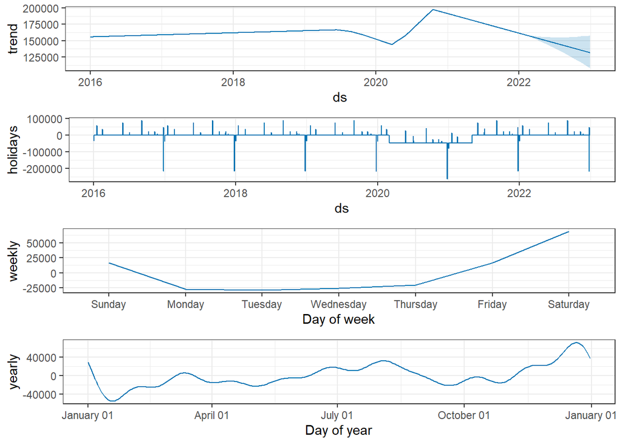

#### Model 2

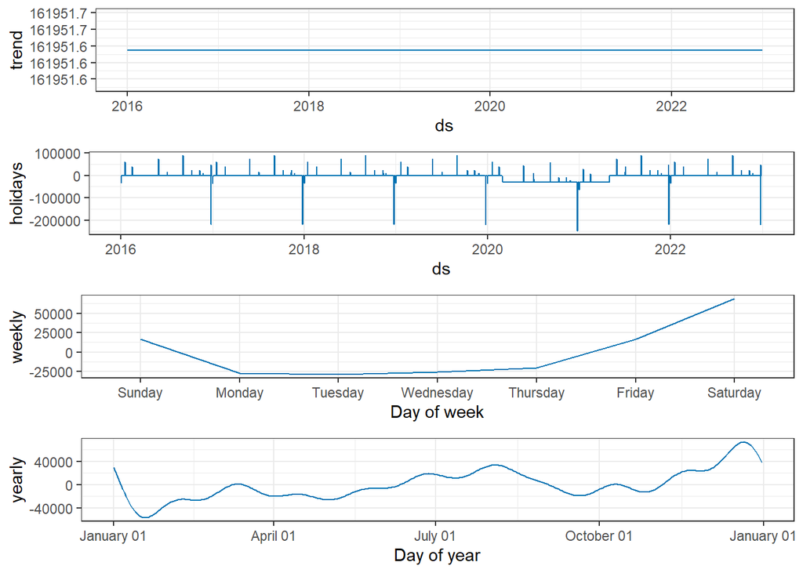

#### Model 3

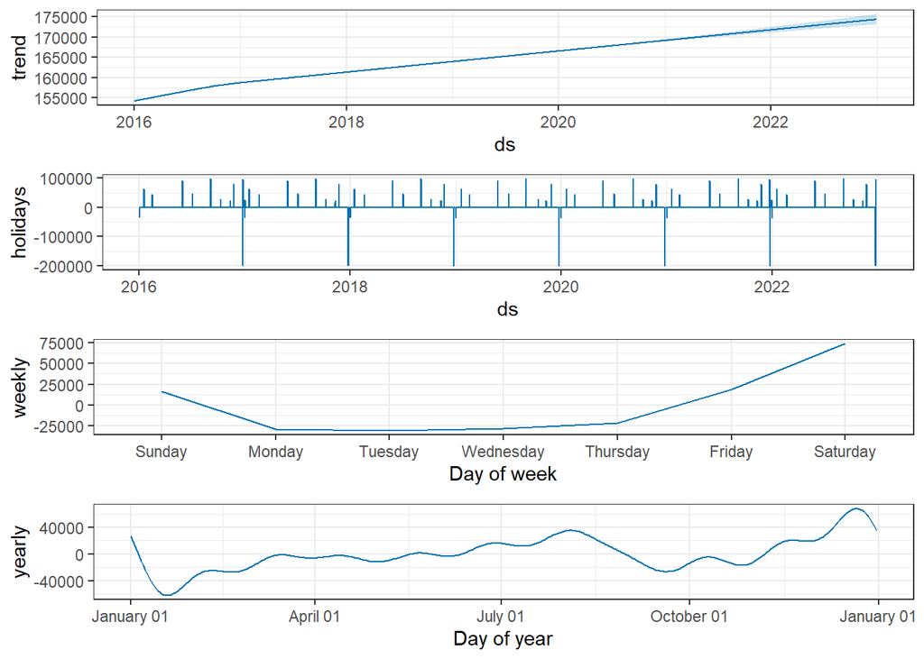

# Next Steps

The “Top Line” section presented both the actuals traffic by month for prior years with the forecasted values for 2022 (bolded).

The forecasted values could represent what would be considered as the baseline for goal setting by the business. Upon which the business leaders responsible for this metric would review and adjust the values according to where they believe they can made an impact. It will be up to the business to determine what strategies they will implement and adjust the goals accordingly.

This analysis body of work is set up to allow for the adjustment of goals based upon the values decided upon by the business owners.

# Appendix

## SQL: Traffic

```sql
with traff as (
select countdate, trafficcount as traffic, trafficcount as vehicleTraffic, 0 as peopletraffic, centerid, conditions, modifiedon, closurestart, closureend, closurereason
FROM [OpsStats].[dbo].[tblTraffic]
where year(countDate) >= '2016'
and countDate < GetDate() -1
and ModifiedOn is not null
and CenterID not in (104) -- removed foxwoods data because shouldn't be captured in this table
UNION ALL

select countdate, trafficcount/3 as traffic, 0 as vehicleTraffic, trafficCount as peopletraffic, centerid, conditions, modifiedon, NULL as closurestart, NULL as closureend, '' as closurereason
FROM [OpsStats].[dbo].[tblPeopleTraffic]
where year(countDate) >= '2016'
and countDate < GetDate() -1
and centerid = 104 --Only pull foxwoods people traffic
)

select t.*, c.entityid, c.description as CenterLocation, c.closed, c.traffictype
FROM traff t left join
   OpsStats.dbo.tblCenter C on t.CenterID = C.CenterID
where c.active = 1
--and t.centerid in (6, 104) --6: Gonzales, 104: Foxwoods
  --and TrafficCount > 0
order by t.centerid, countdate desc
```

## Forecast Model

The forecast model code is available within the I&A OneDrive.